# Applied statistical testing for DM

```r
max(petal_length.sd)/min(petal_length.sd)
```

```
## [1] 3.177945
```

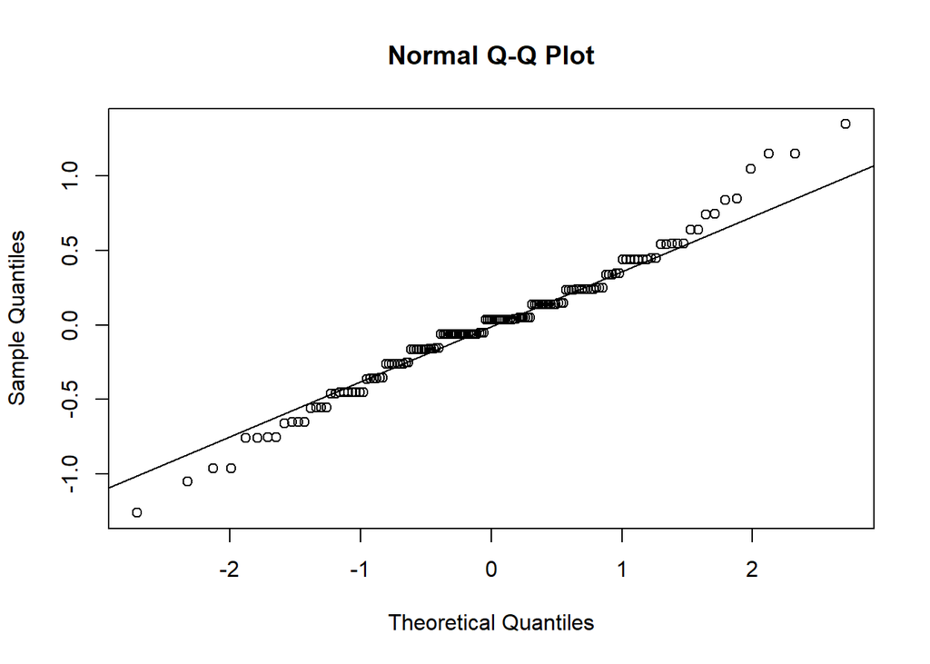

```r
# Variatia din boxplot si raportul variatiilor resping egalitatea variatiilor

# Verificarea normalitatii

qqnorm(petal_length.meancen)
qqline(petal_length.meancen)
```

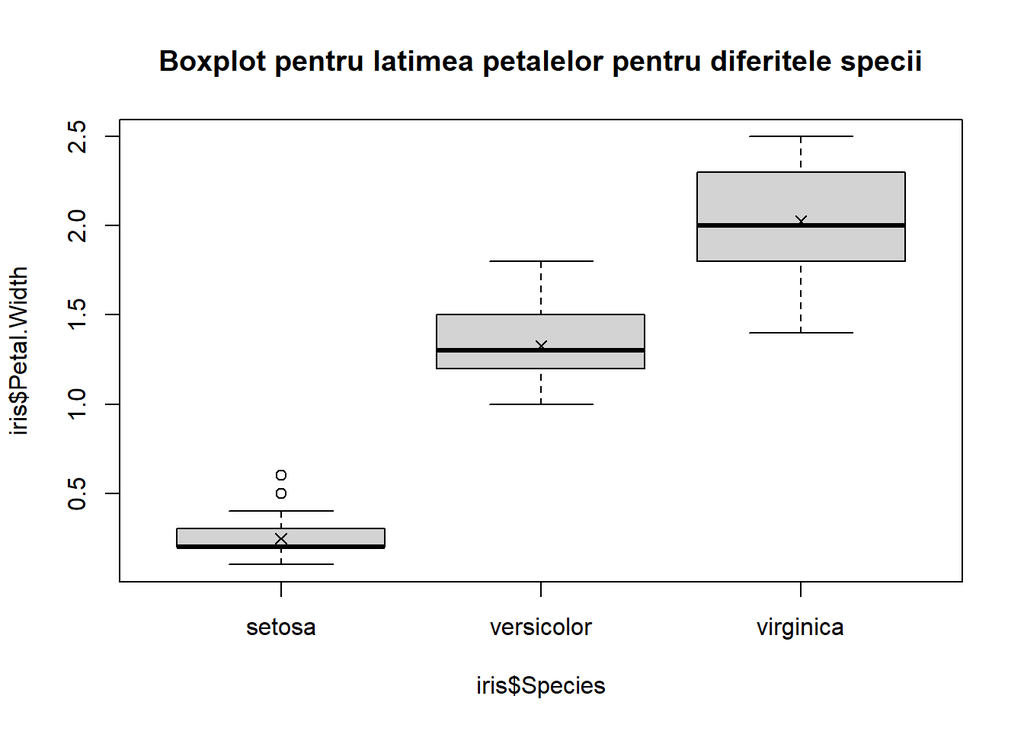

```r
# Graficul ne ofera suficiente informatii pentru a accepta normalitatea datelor.
# Aceasta distribuire a datelor nu este potrivita pentru analiza variantei (ANOVA)

# 4) Petal.width

petal_width.mean<-tapply(iris$Petal.Width,iris$Species,mean)
petal_width.meancen<-iris$Petal.Width-petal_width.mean[as.numeric(iris$Species)]
petal_width.sd<-tapply(iris$Petal.Width,iris$Species,sd)

# Verificarea variatiei

boxplot(iris$Petal.Width~iris$Species, main="Boxplot pentru latimea petalelor pentru diferitele specii")
points(1:3,petal_width.mean,pch=4)
```

```r
max(petal_width.sd)/min(petal_width.sd)
```

```
## [1] 2.606144
```

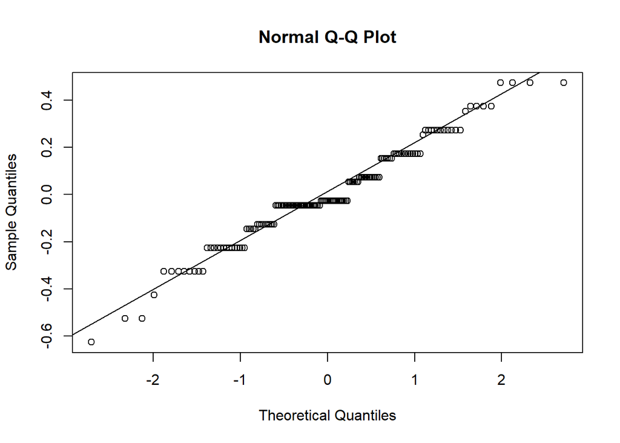

```r
# Variatia din boxplot si raportul variatiilor resping egalitatea variatiilor

# Verificarea normalitatii

qqnorm(petal_width.meancen)
qqline(petal_width.meancen)
```

```r
# Graficul ne ofera suficiente informatii pentru a accepta normalitatea datelor.
# Aceasta distribuire a datelor nu este potrivita pentru analiza variantei (ANOVA)

# Pentru cele mai bune rezultate, cel mai bun set de date pentru analiza variantei (ANOVA)
# Este cel dat de analiza sepalelor (Sepal.width + Sepal.length)

# e
# Generarea tabelului ANOVA folosind aov pentru Sepal.length

sepal_length.aov<-aov(Sepal.Length~Species,iris)
summary(sepal_length.aov)
```

```
##              Df Sum Sq Mean Sq F value Pr(>F)
## Species       2  63.21  31.606   119.3 <2e-16 ***
## Residuals   147  38.96   0.265
## ---
## Signif. codes:  0 '***' 0.001 '**' 0.01 '*' 0.05 '.' 0.1 ' ' 1
```

```r
# Valoarea p-valuea este mult mai mica decat F. Respingem H0

# Generarea tabelului ANOVA folosind aov pentru Sepal.width

sepal_width.aov<-aov(Sepal.Width~Species,iris)
summary(sepal_width.aov)
```

```
##              Df Sum Sq Mean Sq F value Pr(>F)
## Species       2  11.35   5.672   49.16 <2e-16 ***
## Residuals   147  16.96   0.115
## ---
## Signif. codes:  0 '***' 0.001 '**' 0.01 '*' 0.05 '.' 0.1 ' ' 1
```

```r
# Valoarea p-valuea este mult mai mica decat F. Respingem H0
```

## 9. Two-Way ANOVA

În multe studii, variabila numerică de rezultat care ne intereseaza va fi clasificată de mai mult de o singură variabilă de grupare. În aceste cazuri, vom utiliza ANOVA cu factori multipli mai degrabă decât ANOVA cu un singur factor. Această tehnică face referire directă la numărul de variabile de grupare utilizate.

Creșterea numărului de variabile de grupare complică lucrurile oarecum - efectuarea ANOVA cu un singur factor pentru fiecare variabilă în parte este inadecvată. Cand se trateaza un caz cu mai mult de un factor de grupare categorica, trebuie să luam în considerare efectele principale ale fiecărui factor asupra rezultatului numeric, ținând cont în același timp de prezența celorlalti factori de grupare. Totuși, asta nu este tot. Este la fel de important investigam ideea unui efect interactiv; dacă există un efect interactiv, atunci acesta sugerează că impactul pe care una dintre variabilele de grupare îl are asupra rezultatului de interes, specificat de efectul său principal, variază în funcție de nivelurile celorlalte variabile de grupare.

#### 9.1 O suita de ipoteze

Inainte de a enunta ipotezele, vom nota variabila numerica de rezultat cu O si cele doua variabile de grupare cu G1 si G2. Ipotezele pentru ANOVA cu doi factori de grupare sunt urmatoarele:

- H0 : - G1 nu are niciun efect principal (marginal) asupra mediei lui O.

- G2 nu are un efect principal (marginal) asupra mediei lui O.

- Nu există niciun efect interactiv al lui G1 cu G2 asupra mediei lui O.

- HA : Separat, fiecare afirmație din H0 este incorectă.

Ca exemplu vom folosi setul de date predefinit **warpbreaks**. Se va folosi functia **tapply** pentru a observa numarul de rupturi pentru fiecare clasificare:

```r
tapply(warpbreaks$breaks,INDEX=list(warpbreaks$wool,warpbreaks$tension),
FUN=mean)
```

```
##          L        M        H
## A 44.55556 24.00000 24.55556
## B 28.22222 28.77778 18.77778
```

Se pot furniza mai mult de o variabila de grupare pentru argumentul **INDEX** ca membri separati ai unei liste. Rezultatele sunt returnate sub forma unei matrice pentru doua variabile de grupare, o matrice 3D pentru 3 variabile de grupare, si asa mai departe.

Cu toate acestea, pentru anumite analize, este posibil să avem nevoie de aceleași informații furnizate anterior într-un format diferit. Funcția **aggregate** este similară cu **tapply**, dar returnează un dataframe, rezultatele fiind stivuite în funcție de variabilele de grupare specificate. Functia **aggregate** este apelată în același mod ca **tapply**. Primul argument primește vectorul de date interes. Al doilea argument, **by**, trebuie să fie o listă cu variabilele de grupare dorite, iar în **FUN**, se specifică funcția care trebuie să opereze asupra fiecărui subset.

```r
wb.means <- aggregate(warpbreaks$breaks,
by=list(warpbreaks$wool,warpbreaks$tension),FUN=mean)
wb.means
```

```
##   Group.1 Group.2        x
## 1       A       L 44.55556
## 2       B       L 28.22222
## 3       A       M 24.00000
## 4       B       M 28.77778
## 5       A       H 24.55556
## 6       B       H 18.77778
```

#### 9.2 Principalele efecte si interactiuni

Am mentionat mai devreme ca se poate aplica ANOVA cu un singur factor pe fiecare variabila de grupare separat, dar acest lucru, in general, nu este o idee buna. Vom demonstra acum acest lucru:

```r
summary(aov(breaks~wool,data=warpbreaks))
```

```
##             Df Sum Sq Mean Sq F value Pr(>F)
## wool         1    451   450.7   2.668  0.108
## Residuals   52   8782   168.9
```

```r
summary(aov(breaks~tension,data=warpbreaks))
```

```
##             Df Sum Sq Mean Sq F value  Pr(>F)
## tension      2   2034  1017.1   7.206 0.00175 **
## Residuals   51   7199   141.1
## ---
## Signif. codes:  0 '***' 0.001 '**' 0.01 '*' 0.05 '.' 0.1 ' ' 1
```

Problema aici este că, ignorând una dintre variabile, se pierde capacitatea de a detecta diferențele (sau, mai general, relațiile statistice) care pot sa apara la un nivel mai fin. De exemplu, deși numai tipul de lână pare să nu aiba un impact remarcabil asupra numărului mediu de ruperi, nu putem spune dacă acest lucru ar fi valabil dacă doar am analiza tipurile de lână la un anumit nivel de tensiune.

În schimb, vom folosi ANOVA cu doi factori. Urmatorul cod execută ANOVA cu doi factori pentru datele privind rupturile bazate doar pe efectele principale ale celor două variabile de grupare:

```r
summary(aov(breaks~wool+tension,data=warpbreaks))
```

```
##             Df Sum Sq Mean Sq F value  Pr(>F)
## wool         1    451   450.7   3.339 0.07361 .
## tension      2   2034  1017.1   7.537 0.00138 **
## Residuals   50   6748   135.0
## ---
## Signif. codes:  0 '***' 0.001 '**' 0.01 '*' 0.05 '.' 0.1 ' ' 1
```

Observam ca rezultatele arata o scadere mica a valorii p-value, care este acum atasata ambelor variabile de grup. Pentru a interpreta rezultatele, pastram o variabila de grup constanta: pentru un tip de lana, exista dovezi semnificative din punct de vedere statistic care sugereaza o diferenta in ceea ce priveste numarul mediu de rupturi intre diferitele niveluri de tensiune. Pentru un singur nivel de tensiune, dovezile privind o diferență având în vedere cele două tipuri de lână au crescut cu puțin, dar încă nu este semnificativă din punct de vedere statistic (presupunand ca α = 0.05).

Pentru a ține cont de interacțiuni, se face o ușoară ajustare a modelului ANOVA cu doi factori:

```r
summary(aov(breaks~wool+tension+wool:tension,data=warpbreaks))
```

```
##              Df Sum Sq Mean Sq F value   Pr(>F)
## wool          1    451   450.7   3.765 0.058213 .
## tension       2   2034  1017.1   8.498 0.000693 ***
## wool:tension  2   1003   501.4   4.189 0.021044 *
## Residuals    48   5745   119.7
## ---
## Signif. codes:  0 '***' 0.001 '**' 0.01 '*' 0.05 '.' 0.1 ' ' 1
```

Putem interpreta mai detaliat un efect de interactiune a doi factori folosind functia **interaction.plot**:

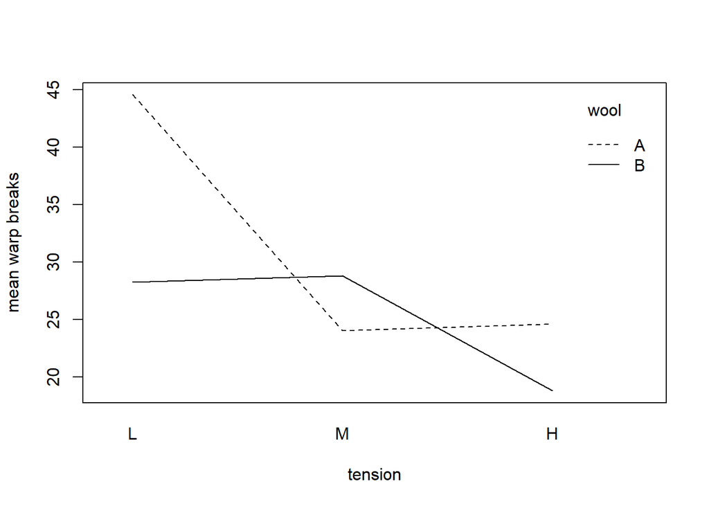

```r
interaction.plot(x.factor=wb.means[,2],trace.factor=wb.means[,1],
response=wb.means$x,trace.label="wool",
xlab="tension",ylab="mean warp breaks")
```

## 10. Testul Kruskal-Waillis

Cand comparam mai multe medii, exista situatii in care nu vrem sa presupunem normalitatea sau constatam ca presupunerea normalitatii nu este valabila in cadrul verificarilor de diagnosticare. In acest caz, se va folosi testul Kruskal Wallis, o alternativa a metodei ANOVA cu un singur factor care relaxeaza dependenta de necesitatea normalitatii. Aceasta metoda testeaza **egalitatea distributiilor** masuratorilor in fiecare nivel al factorului de grupare. Facand presupunerile normale de egalitate a variatiilor intre aceste grupuri, ne vom putea gandi la acest test ca la unul care compara **medianele**, ci nu mediile.

Ipotezele pentru acest test sunt urmatoarele:

- H0 : Medianele grupurilor sunt toate egale
- HA : Medianele grupurilor nu sunt toate egale (alternativ, cel puțin o mediană de grup diferă).

Testul Kruskal-Wallis este o abordare neparametrică, deoarece nu se bazează pe cuantele unei distribuții parametrice standardizate sau oricare dintre funcțiile acesteia.

În cadrul exemplului, se va folosi setul de date **survey** din pachetul **MASS**. Exemplul urmareste sa observe daca varsta studentilor tinde sa difere in ceea ce priveste cele 4 categorii de fumat din *Smoke*. O examinare a boxplotului si a graficului QQ normal al reziduurilor sugereaza ca metoda ANOVA cu un singur factor nu este neaparat o idee buna. Urmatorul cod genereaza boxplotul si graficul QQ normal pentru acest caz:

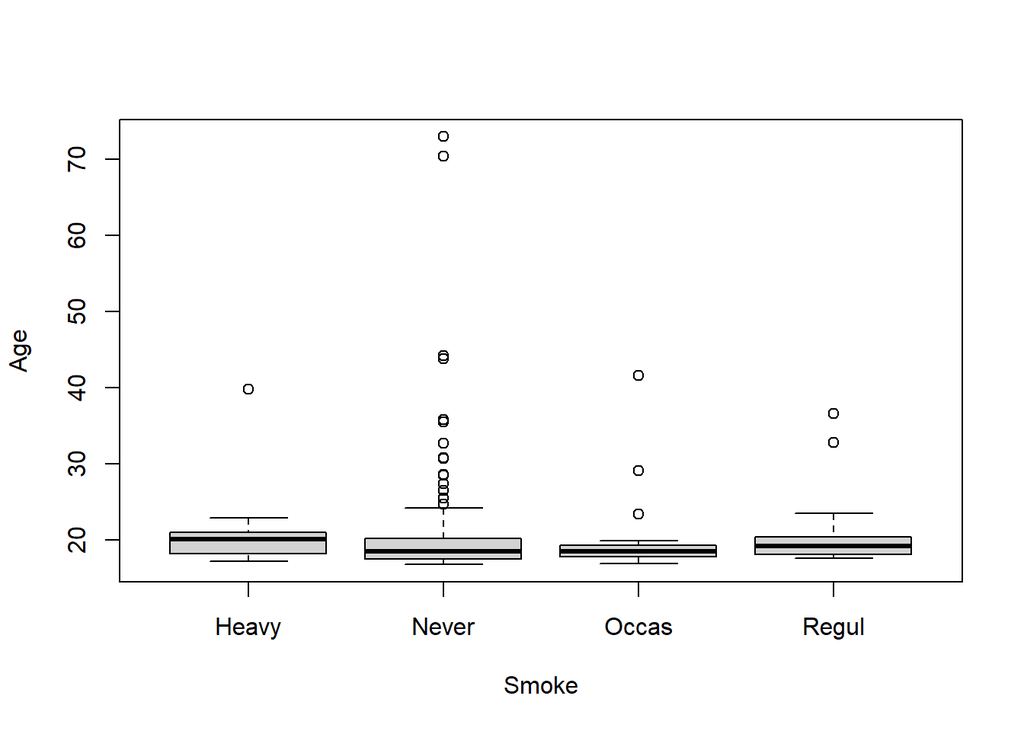

```r
library("MASS")
boxplot(Age~Smoke,data=survey)
```

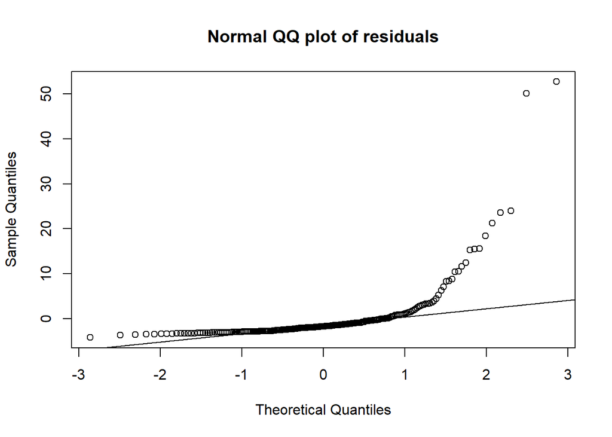

```r
age.means <- tapply(survey$Age,survey$Smoke,mean)
age.meancen <- survey$Age-age.means[as.numeric(survey$Smoke)]
qqnorm(age.meancen,main="Normal QQ plot of residuals")
qqline(age.meancen)
```

Cu această posibilă încălcare a normalității, putem aplica testul Kruskal-Wallis în loc de testul parametric ANOVA. O verificare rapidă pentru egalitatea varianțelor susține și mai mult acest lucru, cu raportul dintre cea mai mare și cea mai mica deviatie standard fiind în mod clar mai mic decat 2:

```r
survey.sds<-tapply(survey$Age,survey$Smoke,sd)
max(survey.sds)/min(survey.sds)
```

```
## [1] 1.234142
```

Un test Kruskal-Wallis este efectuat folosind functia **kruskal.test**:

```r
kruskal.test(Age~Smoke,data=survey)
```

```
##
##  Kruskal-Wallis rank sum test
##
## data:  Age by Smoke
## Kruskal-Wallis chi-squared = 3.9262, df = 3, p-value = 0.2695
```

#### Exercitiul 10

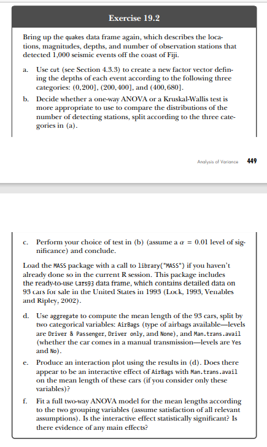

#### Exercitiul 10 - Rezolvare

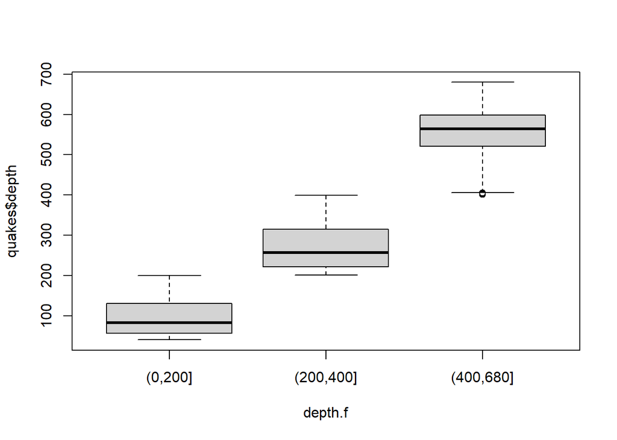

```r
# a

depth.f<-cut(quakes$depth,breaks=c(0,200,400,680),include.lowest = F)

# b
# Se verifica egalitatea variatiilor si normalitatea

boxplot(quakes$depth~depth.f)
```

```r
depth.sd<-tapply(quakes$depth,depth.f,sd)
max(depth.sd)/min(depth.sd)
```

```
## [1] 1.310495
```

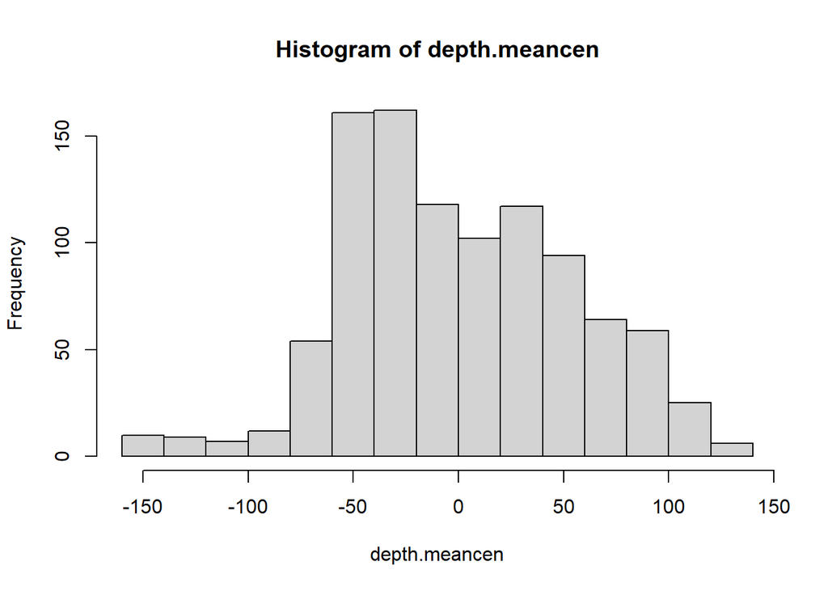

```r
depth.mean<-tapply(quakes$depth,depth.f,mean)
depth.meancen<-quakes$depth-depth.mean[as.numeric(depth.f)]
hist(depth.meancen)
```

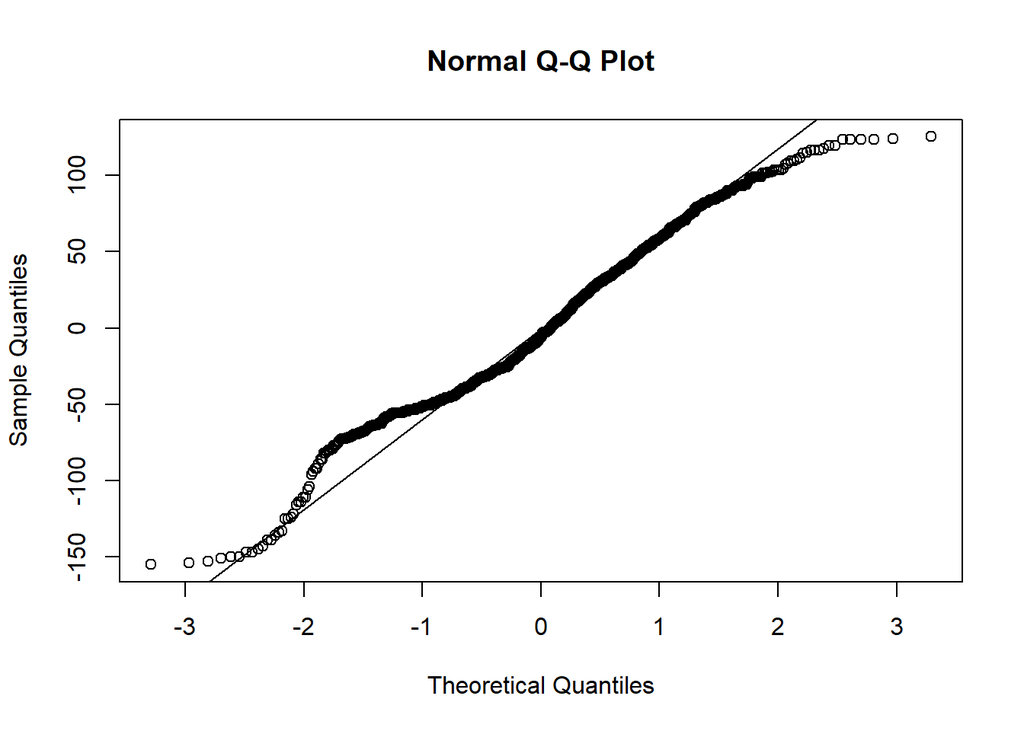

```r
qqnorm(depth.meancen)
qqline(depth.meancen)
```

```r
# Atat egalitatea variatiilor, cat si normalitatea distributiei sunt acceptate
# Ceea ce inseamna ca putem aplica testul ANOVA

# c

summary(aov(quakes$depth~depth.f))
```

```
##              Df   Sum Sq  Mean Sq F value Pr(>F)
## depth.f       2 43498641 21749320    7450 <2e-16 ***
## Residuals   997  2910455     2919
## ---
## Signif. codes:  0 '***' 0.001 '**' 0.01 '*' 0.05 '.' 0.1 ' ' 1
```

```r
# Valoarea foarte mica a p-value (p-value < 0.01) sugereaza ca nu toate mediile sunt egale
# Ha este ipoteza acceptata

# d

cars.mean<-aggregate(Cars93$Length,
          by=list(Airbags=Cars93$AirBags,
                  ManualTransmission=Cars93$Man.trans.avail),
          FUN=mean)
cars.mean
```

```
##              Airbags ManualTransmission        x
## 1 Driver & Passenger                 No 197.5000
## 2        Driver only                 No 197.8750
## 3               None                 No 191.3750
## 4 Driver & Passenger                Yes 189.0000
## 5        Driver only                Yes 178.0370
## 6               None                Yes 170.8462
```

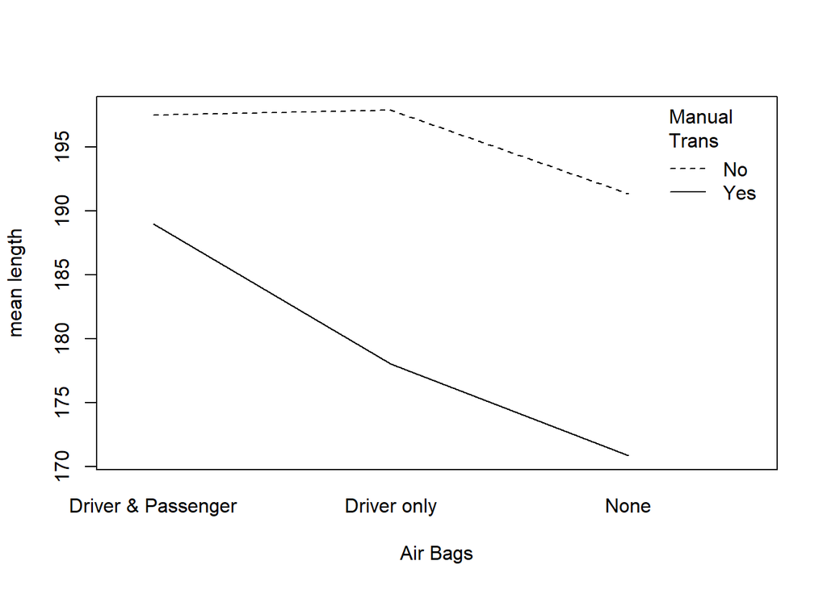

```r
# e

interaction.plot(cars.mean[,1],
                 cars.mean[,2],
                 response=cars.mean[,3],
                 xlab = "Air Bags",
                 ylab="mean length",
                 trace.label = "Manual\n   Trans")
```

```r
# Graficul sugereaza ca exista o interactiune intre Airbags si Manual transmission
# Considerand doar aceste doua variabile

# f

summary(aov(Length~AirBags+Man.trans.avail+AirBags:Man.trans.avail,Cars93))
```

```
##                         Df Sum Sq Mean Sq F value   Pr(>F)
## AirBags                  2   3752    1876  18.048 2.78e-07 ***
## Man.trans.avail          1   6388    6388  61.447 1.05e-11 ***
## AirBags:Man.trans.avail  2    433     217   2.084    0.131
## Residuals               87   9044     104
## ---
## Signif. codes:  0 '***' 0.001 '**' 0.01 '*' 0.05 '.' 0.1 ' ' 1
```

```r
# Nu sunt suficiente dovezi statistice pentru efectul interactiunii
# Dar putem confirma efectul principal al ambelor variabile asupra lungimii
```